# Связь ориентации камбал с их размером в разных заливах Белого моря

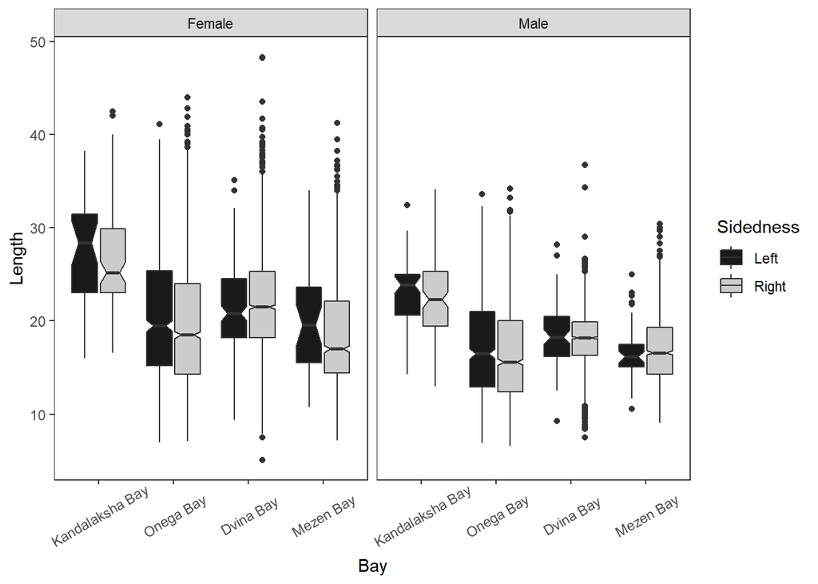

**Рисунок 3.** Характеристика размерного состава камбал в разных заливах Белого моря.

Таблица 2. Средние размеры (± Стандартная ошибка) камбал разной ориентации и разного пола.

| Bay | Female Left |  |  | Female Right |  |  |  | Male Left |  |  | Male Right |  |  |  |
| --- | --- | --- | --- | --- | --- | --- | --- | --- | --- | --- | --- | --- | --- | --- |
| Kandalaksha Bay | 27.6 | ± | 1.03 | 26.3 | ± | 0.60 |  | 23.0 | ± | 0.44 | 22.5 | ± | 0.37 |  |
| Onega Bay | 20.4 | ± | 0.26 | 19.5 | ± | 0.15 |  | 17.3 | ± | 0.23 | 16.4 | ± | 0.13 |  |
| Dvina Bay | 21.3 | ± | 0.37 | 21.9 | ± | 0.10 |  | 18.5 | ± | 0.39 | 18.1 | ± | 0.07 |  |
| Mezen Bay | 20.2 | ± | 0.97 | 18.7 | ± | 0.17 |  | 16.7 | ± | 0.52 | 16.9 | ± | 0.11 |  |

Для анализа связи частоты встречаемости левосторонних особей с размером и полом рыб в рассматриваемых выборках была построена логистическая регрессионная модель, основанная на биномиальном распределении отклика. Для подбора параметров данной модели рыб с левосторонней ориентацией кодировали, как 1, в рыб с правосторонне – как 0. В качестве пердикторов в модели выступали переменные “*Bay*” (дискретный фактор с четырьмя градациями), “*Sex*” (дискретный фактор с двумя градациями), “*Length*” (непрерывная ковариата) и все возможные взаимодействия предикторов. Поскольку статистически значимого взаимодействия предикторов в полной модели выявлено не было, модель была упрощена в соответствии с протоколом обратного пошагового отбора. Параметры финальной модели представлены в табл. 3. Анализ девиансы финальной модели (табл. 4) показал что все предикторы, включенные в модель, оказывают значимое влияние на вероятность встречи реверсивных особей.

**Таблица 3.** Параметры финальной модели, описывающей связь веротяности встречи реверсивных камбал с размером, полом и точкой отлова

| term | estimate | std.error | statistic | p.value |
| --- | --- | --- | --- | --- |
| (Intercept) | -1.322 | 0.179 | -7.402 | 0.000 |
| L | 0.020 | 0.005 | 4.144 | 0.000 |
| SexMale | 0.123 | 0.059 | 2.081 | 0.037 |
| BayOnega Bay | -0.147 | 0.129 | -1.139 | 0.255 |
| BayDvina Bay | -2.042 | 0.140 | -14.591 | 0.000 |
| BayMezen Bay | -2.461 | 0.171 | -14.378 | 0.000 |

**Таблица 4.**Анализ девиансы финальной модели

| term | statistic | df | p.value |
| --- | --- | --- | --- |
| L | 17.041 | 1 | 0.000 |
| Sex | 4.325 | 1 | 0.038 |
| Bay | 1227.736 | 3 | 0.000 |